# Chip-seq in Galaxy and R

Emily Chambers

Last modified: 27 Jul 2020

# Hands-on chip-seq Analysis in Galaxy and R

### Sheffield Bioinformatics Core

web : sbc.shef.ac.uk  
twitter: SheffBioinfCore  
email: bioinformatics-core@sheffield.ac.uk

# Acknowledgement

- [ATAC-Seq data analysis in Galaxy](https://training.galaxyproject.org/training-material/topics/epigenetics/tutorials/atac-seq/tutorial.html/)
- [Chip-seq excersizes in R by Jonas Ibn-Salem, JGU Mainz](http://cbdm-01.zdv.uni-mainz.de/~jibnsale/teaching/chip-seq_exercises.html)
- [The ChIPpeakAnno user’s guide by Jianhong Ou, Jun Yu, Lihua Julie Zhu](https://www.bioconductor.org/packages/release/bioc/vignettes/ChIPpeakAnno/inst/doc/ChIPpeakAnno.html)

# Tutorial overview

This tutorial will continue the analysis of the ChIP-seq peak data that we squired in part 1. Let’s have another look at our workflow. We now have our chip-seq peaks called in a bed file and are ready for our downstream analysis.

[figure not shown]

For the purposes of looking at peak annotation and enrichments we will look at the complete peak data for the breast cancer dataset. In part 1 we examined a smaller subset of this data in order to carry out alignments and peak calling within a shorter time frame. The next part of our analysis involves annotating our peaks, carrying out a differential peak enrichment analysis and visualisations.

# Working in Rstudio

For the second part of the analysis we will move onto using the R programming language in RStudio. R is a very useful tool for quickly manipulating and visualising biological data and will allow us to visualise, annotate and investigate our peak data. You can get more information on R and the Sheffield Bioinformatics Core online training materials [here](https://sbc.shef.ac.uk/training/r-introduction-2020-03-03/).

Organising your R analyses into project is good practice for keeping all files relevant to a particular piece of work in one place. Open up RStudio and create a new project:

**File > New Project > Existing Directory > …choose workshop material directory**

We’ve now turned our workshop material folder into an Rstudio project and launched it.

We’ll also be carrying out our analysis in an R Notebook which allow us keep each R code in executable chunks with output visible immediately beneath the input.

Let’s open an R Notebook to start work in.

**File > New File > R notebook**

# Required R packages

In this afternoons analysis we will need to use several R packages. If you have not already done so, please install the packages we will need for the analysis using the code chunk below.

```r
if(!require(ChIPpeakAnno)) BiocManager::install("ChIPpeakAnno")
if(!require(TxDb.Hsapiens.UCSC.hg18.knownGene)) BiocManager::install("TxDb.Hsapiens.UCSC.hg18.knownGene")
if(!require(org.Hs.eg.db))BiocManager::install("org.Hs.eg.db")
if(!require(dplyr)) BiocManager::install("dplyr")
if(!require(rtracklayer)) BiocManager::install("rtracklayer")
if(!require(reactome.db)) BiocManager::install("reactome.db")
```

# Upload Data

```r
FOXA1_df <- read.table("data/FOXA1_full.bed", header=TRUE)
head(FOXA1_df)
```

|  | chr | start | end | length | summit | tags | X.10.log10.pvalue. | fold_enrichment | FDR... |
| --- | --- | --- | --- | --- | --- | --- | --- | --- | --- |
| 1 | chr1 | 8250 | 8671 | 422 | 286 | 46 | 145.84 | 11.68 | 0.51 |
| 2 | chr1 | 36382 | 36984 | 603 | 405 | 46 | 315.23 | 27.05 | 0.24 |
| 3 | chr1 | 70082 | 70475 | 394 | 273 | 14 | 65.40 | 9.74 | 1.13 |
| 4 | chr1 | 389664 | 390025 | 362 | 118 | 13 | 62.30 | 7.57 | 1.19 |
| 5 | chr1 | 414083 | 414588 | 506 | 279 | 41 | 234.60 | 21.95 | 0.33 |
| 6 | chr1 | 449089 | 450054 | 966 | 665 | 90 | 368.81 | 20.10 | 0.19 |

```r
ER_df <- read.table("data/ER_full.bed", header=TRUE)
head(ER_df)
```

|  | chr | start | end | score |
| --- | --- | --- | --- | --- |
| 1 | chr1 | 846288 | 846544 | 0.11424343 |
| 2 | chr1 | 920942 | 921363 | 0.08396987 |
| 3 | chr1 | 998506 | 999838 | 0.40433558 |
| 4 | chr1 | 1004632 | 1005377 | 0.19387302 |
| 5 | chr1 | 1049926 | 1050719 | 0.05081018 |
| 6 | chr1 | 1061720 | 1062079 | 0.12064781 |

```r
NA
```

# Convert to a GRanges object

The next step is to convert our uploaded data frames into a GRanges object for further analysis. A GRanges object from the GenomicRanges package is a container for genomic locations and their associated annotations and so is perfect for us to deal with our ChIP-seq peak coordinates.

Here is the R code for converting the FOXA1 data into a GRanges object…

```r
library(GenomicRanges) # load the GenomicRanges package

FOXA1 <- GRanges(
  FOXA1_df$chr,
  IRanges(FOXA1_df$start, FOXA1_df$end),
  strand="*"
)

# we can add more data to each peak subsequently
score(FOXA1) <- FOXA1_df[,"X.10.log10.pvalue."]

# show the first and last lines of the GRanges object
FOXA1
```

```
GRanges object with 95314 ranges and 1 metadata column:
          seqnames            ranges strand |     score
             <Rle>         <IRanges>  <Rle> | <numeric>
      [1]     chr1         8250-8671      * |    145.84
      [2]     chr1       36382-36984      * |    315.23
      [3]     chr1       70082-70475      * |      65.4
      [4]     chr1     389664-390025      * |      62.3
      [5]     chr1     414083-414588      * |     234.6
      ...      ...               ...    ... .       ...
  [95310]     chrY 27226584-27227719      * |     67.62
  [95311]     chrY 57228665-57327117      * |      3100
  [95312]     chrY 57428755-57429933      * |   1646.77
  [95313]     chrY 57436997-57437537      * |     54.18
  [95314]     chrY 57551525-57551838      * |     51.13
  -------
  seqinfo: 24 sequences from an unspecified genome; no seqlengths
```

… and the ER data.

The ER data is in a slightly different format. If you look at the raw data you will see that the FOXA1_full.bed file has all the columns from the MACS2 output and the ER_full.bed file is in a more traditional bed format (chr, start, end, score). This was how the lab released their full data online. Sometimes when dealing with publicly available data these kinds of discrepencies can occur. Most importantly it doesn’t affect our downstream analysis of the peaks.

```r
ER <- GRanges(
  ER_df$chr,
  IRanges(ER_df$start, ER_df$end),
    strand="*"
)

# we can add more data to each peak subsequently
score(ER) <- ER_df$score


# show the first and last lines of the GRanges object
ER
```

```
GRanges object with 12999 ranges and 1 metadata column:
          seqnames            ranges strand |              score
             <Rle>         <IRanges>  <Rle> |          <numeric>
      [1]     chr1     846288-846544      * |  0.114243427848363
      [2]     chr1     920942-921363      * | 0.0839698748765652
      [3]     chr1     998506-999838      * |  0.404335575562571
      [4]     chr1   1004632-1005377      * |   0.19387301910821
      [5]     chr1   1049926-1050719      * | 0.0508101787980254
      ...      ...               ...    ... .                ...
  [12995]     chrY 11948845-11948929      * |  0.264330981850441
  [12996]     chrY 57394535-57394602      * |   0.22452241426891
  [12997]     chrY 57395444-57395564      * |  0.335700586987822
  [12998]     chrY 57402652-57402756      * |  0.260627565261645
  [12999]     chrY 57405864-57406005      * |  0.183393351786731
  -------
  seqinfo: 24 sequences from an unspecified genome; no seqlengths
```

# Basic peak statistics

Now we have loaded in the peaks and converted into a GRanges object, we can carry out some basic statistical analysis and plot simple visualisations. We will do this for the FOXA1 peaks.

## Calculate the number of peaks

The length() function assesses the number of datapoints (peaks) in the FOXA1 object

```r
length(FOXA1)
```

```
[1] 95314
```

## Calculate mean, median, and max size of the peaks

The function width() returns the sizes of all ranges in a GRanges object as vector.

```r
FOXA1.size <- width(FOXA1)
summary(FOXA1.size)
```

```
   Min. 1st Qu.  Median    Mean 3rd Qu.    Max.
  142.0   426.0   538.0   594.9   682.0 98453.0
```

## Visualisations of peaks

We can remove unusually large peak widths by assigning a threshold and removing peaks that are larger than it.

```r
FOXA1 <- FOXA1[width(FOXA1) <= 2000]
```

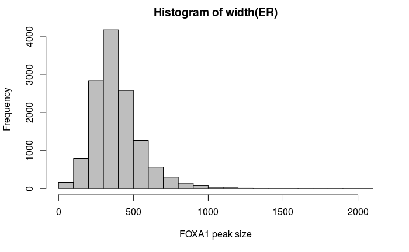

```r
hist(width(ER), xlab="FOXA1 peak size", col="gray")
```

We may want to look at the distribution of the pvalues associated with each peak. When assigning the GRanges objects earlier, we saved the pvalues in the ‘score’ column. We can access this data and plot another histogram.

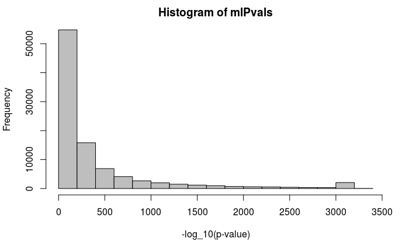

```r
# get the -log_10 transformed p-values from the score column
mlPvals <- score(FOXA1)
hist(mlPvals, xlab="-log_10(p-value)", col="gray")
```

## Exercise

**We have carried out basic stats and peak visualsations for the FOXA1 data, now do the same for the ER data.**

# Compare the peaks of ER and FOXA1

Now we have both datasets loaded as GRanges objects and done some basic stats to ensure our data looks OK we can start comparing peaks across both datasets. Let’s start by plotting a simple barplot.

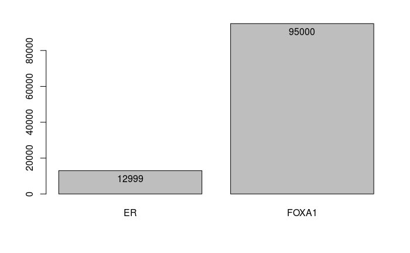

```r
bp <- barplot(c(length(ER), length(FOXA1)), names=c("ER", "FOXA1"))
# add actual values as text lables to the plot
text(bp, c(length(ER), length(FOXA1)), labels=c(length(ER), length(FOXA1)), pos=1)
```

To get the number of overlaps across the peaks we will use the functions from the package `ChIPpeakAnno`. ‘findOverlapsOfPeaks’ is a function that finds the overlaps between two GRanges objeects.

## How many ER peaks overlap FOXA1 peaks?

```r
# find overlap of binding sites
ovlHits <- findOverlapsOfPeaks(ER, FOXA1)
ovlHits$venn_cnt
```

```
     ER FOXA1 Counts
[1,]  0     0      0
[2,]  0     1  87068
[3,]  1     0   4823
[4,]  1     1   7924
attr(,"class")
[1] "VennCounts"
```

```r
overlaps <- ovlHits$peaklist[["ER///FOXA1"]]
```

We can use this overlap data to plot a Venn Diagram

```
$p.value
     ER FOXA1 pval
[1,]  1     1    1

$vennCounts
     ER FOXA1 Counts
[1,]  0     0      0
[2,]  0     1  87068
[3,]  1     0   4823
[4,]  1     1   7924
attr(,"class")
[1] "VennCounts"
```

[figure not shown]

```r
makeVennDiagram(list(ER, FOXA1), NameOfPeaks=c("ER", "FOXA1"),
                scaled=FALSE,
                fill=c("#009E73", "#F0E442")) # circle fill color
```

A pie chart is used to demonstrate the overlap features of the common peaks.

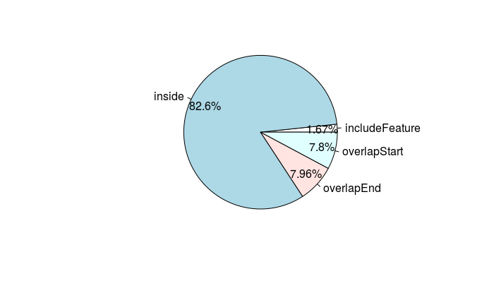

```r
pie1(table(ovlHits $overlappingPeaks[["ER///FOXA1"]]$overlapFeature))
```

# Functional annotation of ChIP-seq peaks

To understand the function of a transcription factor we want to know to which genes and genomic features it binds. We will use a TxDb objects. Such an object is an R interface to prefabricated databases contained by specific annotation packages. The package TxDb.Hsapiens.UCSC.hg18.knownGene includes all human genes and transcripts from UCSC with coordinates for the hg18 genome assembly.

```r
library(TxDb.Hsapiens.UCSC.hg18.knownGene)
txdb <- TxDb.Hsapiens.UCSC.hg18.knownGene # just a shortcut

## create annotation file from EnsDb or TxDb
annoData <- toGRanges(txdb, feature="gene")
annoData[1:2]
```

```
GRanges object with 2 ranges and 0 metadata columns:
     seqnames            ranges strand
        <Rle>         <IRanges>  <Rle>
   1    chr19 63549984-63565932      -
  10     chr8 18293035-18303003      +
  -------
  seqinfo: 49 sequences (1 circular) from hg18 genome
```

```r
rtracklayer::export(annoData, con="TxDb.Hsapiens.UCSC.hg18.gene.bed")
```

Now we overlap the annotation to the peaks

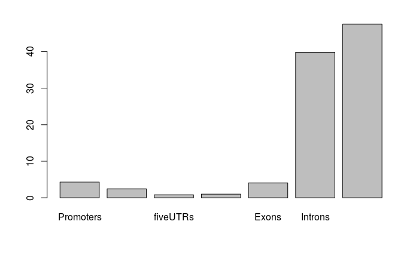

```r
overlaps_anno <- annotatePeakInBatch(overlaps, AnnotationData=annoData,
                                    output="overlapping", maxgap=5000L)


aCR<-assignChromosomeRegion(overlaps_anno, nucleotideLevel=FALSE,
                           precedence=c("Promoters", "immediateDownstream",
                                         "fiveUTRs", "threeUTRs",
                                         "Exons", "Introns"),
                           TxDb=TxDb.Hsapiens.UCSC.hg18.knownGene)
barplot(aCR$percentage)
```

Add the gene names to the annotation and write out as `csv` and `bed` files.

```r
library(dplyr)
library(org.Hs.eg.db)
overlaps_anno <- addGeneIDs(overlaps_anno, org.Hs.eg.db, IDs2Add = c("symbol","refseq", "ensembl"),
feature_id_type = "entrez_id")



as.data.frame(unname(overlaps_anno)) %>%
  dplyr::select(-peakNames,-peak) %>%
  readr::write_csv("overlap_peaks_annotated.csv")

names(overlaps_anno) <- lapply(overlaps_anno$peakNames, function(x) paste(x,collapse=":"))
names(overlaps_anno) <- paste(overlaps_anno$feature,names(overlaps_anno),sep="_")


rtracklayer::export(overlaps_anno, con="overlap_peaks.bed")
```

## Enrichment with ChIPpeakAnno

Use functionality within ChIPpeakAnno to perform enrichment (see package vignette).

|  | go.id | go.term | Definition | Ontology | pvalue | count.InDataset | count.InGenome | totaltermInDataset | totaltermInGenome | BH.adjusted.p.value | EntrezID |
| --- | --- | --- | --- | --- | --- | --- | --- | --- | --- | --- | --- |
| 1 | GO:0000122 | negative regulation of transcription by RNA polymerase II | Any process that stops, prevents, or reduces the frequency, rate or extent of transcription mediated by RNA polymerase II. | BP | 2.435934e-04 | 161 | 735 | 249009 | 1476651 | 2.403235e-02 | 4734;9611;9612;3337;9531;138151;4781;5155;5467;652;6662;9759;10062;1021;1045;10468;1050;10507;10664;11060;1407;148979;153090;1602;1649;165631;1786;1788;1877;1906;1942;1991;2063;2099;2100;2117;2120;218… |
| 2 | GO:0000902 | cell morphogenesis | The developmental process in which the size or shape of a cell is generated and organized. | BP | 9.005210e-10 | 218 | 874 | 249009 | 1476651 | 4.635882e-06 | 9113;26084;3397;80781;23022;23094;2317;353116;367;64919;79977;79983;122786;57669;10458;1267;2263;22854;4744;4897;51761;56288;57731;596;80128;1002;10512;1400;151449;1826;2049;2131;23114;2534;2674;2736;… |
| 3 | GO:0000904 | cell morphogenesis involved in differentiation | The change in form (cell shape and size) that occurs when relatively unspecialized cells, e.g. embryonic or regenerative cells, acquire specialized structural and/or functional features that character… | BP | 9.707675e-09 | 163 | 632 | 249009 | 1476651 | 1.609371e-05 | 9113;26084;3397;80781;23022;23094;2317;353116;367;64919;79977;79983;122786;57669;10458;1267;2263;22854;4744;4897;51761;56288;57731;596;80128;1002;10512;1400;151449;1826;2049;2131;23114;2534;2674;2736;… |
| 4 | GO:0001101 | response to acid chemical | Any process that results in a change in state or activity of a cell or an organism (in terms of movement, secretion, enzyme production, gene expression, etc.) as a result of a stimulus by the chemical… | BP | 6.411174e-04 | 79 | 330 | 249009 | 1476651 | 4.475305e-02 | 231;928;375611;5727;1906;847;1786;1788;22849;23677;26012;4915;57521;598;824;9148;1244;10626;1512;1592;360;5468;5914;5916;6256;6720;9536;2950;3673;1236;2695;4067;57707;6506;2934;4255;3856;80781;2696;94… |
| 5 | GO:0001558 | regulation of cell growth | Any process that modulates the frequency, rate, extent or direction of cell growth. | BP | 7.064153e-04 | 92 | 396 | 249009 | 1476651 | 4.632645e-02 | 26153;102;10519;2064;207;2185;3249;57521;596;6195;6280;6548;6832;7042;84678;9211;9472;123879;183;203245;2100;23677;2786;29948;3172;323;4088;5167;5467;5468;5795;623;6586;6595;6597;694;79602;79960;84722… |
| 6 | GO:0001655 | urogenital system development | The process whose specific outcome is the progression of the urogenital system over time, from its formation to the mature structure. | BP | 3.571832e-04 | 79 | 324 | 249009 | 1476651 | 3.039304e-02 | 1512;3399;51107;596;6092;80000;168667;2263;2296;4088;4091;5914;5979;6382;6385;652;847;170690;5087;5228;5727;6662;79633;1592;183;23371;25976;2736;403;4326;4357;5176;5314;5629;64220;7020;7042;7161;7380;… |

## Enrichment with Reactome

```r
library(reactome.db)
path <- getEnrichedPATH(overlaps_anno, "org.Hs.eg.db","reactome.db", maxP = 0.05,feature_id_type="entrez_id" ) %>%
  rename(ENTREZID = EntrezID)

gene_anno <- AnnotationDbi::select(org.Hs.eg.db, keys = as.character(path$ENTREZID), keytype="ENTREZID",columns="SYMBOL")

path_anno <- AnnotationDbi::select(reactome.db, keys = as.character(path$path.id),
                                   keytype="PATHID",
                                   columns=c("PATHID","PATHNAME")) %>% rename(path.id = PATHID)

path %>% left_join(gene_anno) %>%
  group_by(path.id) %>%
  mutate(Genes = paste(unique(SYMBOL),collapse=";")) %>%
  ungroup %>%
  filter(!duplicated(path.id)) %>%
  left_join(path_anno) %>%
  distinct %>%
  select(-ENTREZID, -PATH, -totaltermInDataset, -totaltermInGenome, -SYMBOL)  %>%
  arrange(pvalue) %>%
  write_csv("overlap_peaks_reactome.csv")
```